# Latihan 5

# Library

```r
library(ggplot2)
library(tsibble)
library(tseries)
library(MASS)
library(dplyr)
```

# Import Data

```r
data <- read.csv("C:/Users/LENOVO/Downloads/Reversed Bitcoin Historical Price.csv")
head(data)
```

```
##         Date Price  Open  High   Low    Vol. Change..
## 1 01/03/2016 448.3 433.7 462.9 423.1 457.61K    3.36%
## 2 01/10/2016   385 448.3 451.1 350.4 735.95K  -14.11%
## 3 01/17/2016 388.6   385 425.7 373.2 688.23K    0.93%
## 4 01/24/2016 377.8 388.6 405.4 363.5 484.64K   -2.79%
## 5 01/31/2016 376.7 377.8 391.8 365.3 465.80K   -0.29%
## 6 02/07/2016 390.1 376.7 392.6 371.4 420.40K    3.56%
```

```r
dt <- data[, c("Date", "Price")]
dt <- dt[1:126, ]
head(dt)
```

```
##         Date Price
## 1 01/03/2016 448.3
## 2 01/10/2016   385
## 3 01/17/2016 388.6
## 4 01/24/2016 377.8
## 5 01/31/2016 376.7
## 6 02/07/2016 390.1
```

```r
dt$Date <- as.Date(dt$Date, format = "%m/%d/%Y")
dt$Price <- as.numeric(gsub(",", "", dt$Price))
```

```r
dt.ts <- ts(dt$Price)
```

# Plot Time Series

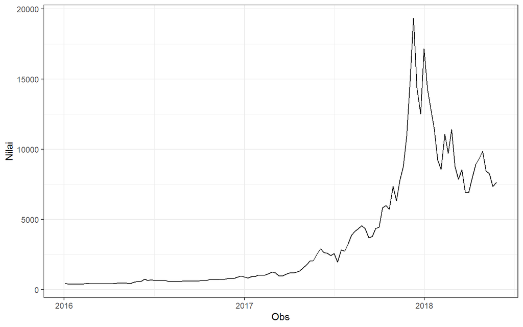

```r
plot_dt <- dt.ts |> as_tsibble() |>
  ggplot(aes(x = dt$Date, y = dt$Price)) + geom_line() + theme_bw() +
  xlab("Obs") + ylab("Nilai")
plot_dt
```

Berdasarkan plot time series tersebut, terlihat bahwa data tidak stasioner dalam rataan, ditandai dengan adanya trend pada data dan tidak stasioner dalam ragam, ditandai dengan adanya perbedaan lebar pita pada plot.

# Pembagian Data

```r
# hitung jumlah data
n <- nrow(dt)

# tentukan batas 6a5% (menyesuaikan karakteristik data)
n_train <- floor(0.65 * n)

# bagi data
training <- dt[1:n_train, ]
testing  <- dt[(n_train+1):n, ]

# ubah ke time series
train.ts <- ts(training$Price)
test.ts  <- ts(testing$Price)
```

# Plot Time Series

## Data Train

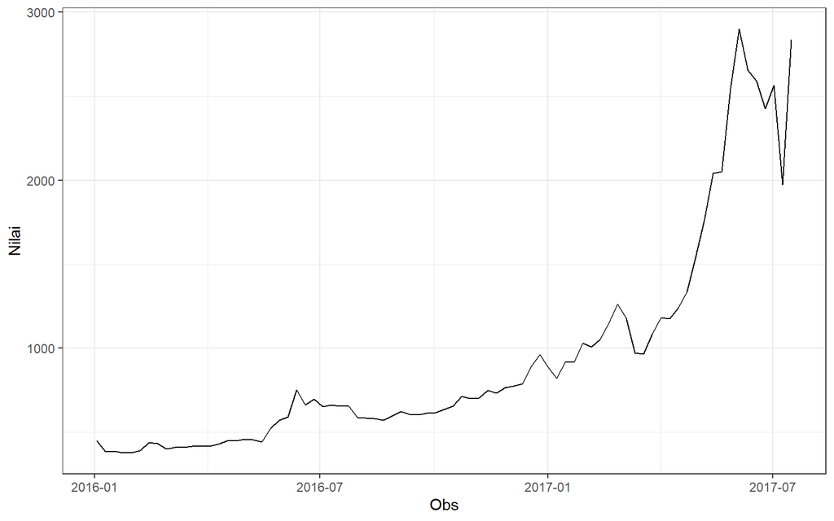

```r
plot_dt1 <- train.ts |> as_tsibble() |>
  ggplot(aes(x = training$Date, y = training$Price)) + geom_line() + theme_bw() +
  xlab("Obs") + ylab("Nilai")
plot_dt1
```

Berdasarkan plot time series tersebut, terlihat bahwa data train tidak stasioner dalam rataan, ditandai dengan adanya trend pada data dan tidak stasioner dalam ragam, ditandai dengan adanya perbedaan lebar pita pada plot.

## Data Test

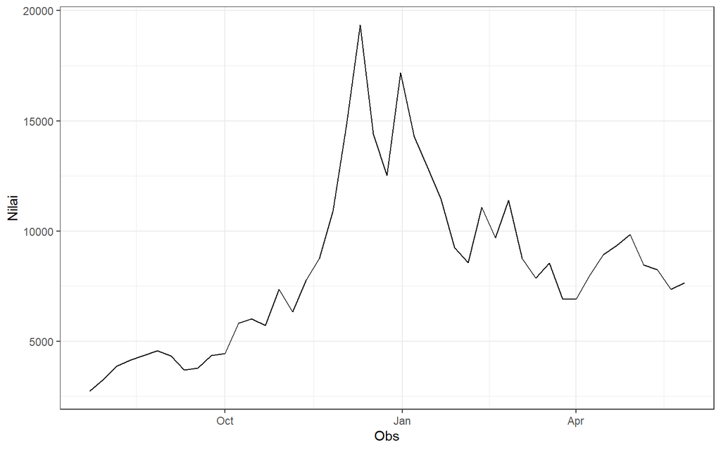

```r
plot_dt2 <- test.ts |> as_tsibble() |>
  ggplot(aes(x = testing$Date, y = testing$Price)) + geom_line() + theme_bw() +
  xlab("Obs") + ylab("Nilai")
plot_dt2
```

Berdasarkan plot time series tersebut, terlihat bahwa data test tidak stasioner dalam rataan, ditandai dengan adanya trend pada data dan tidak stasioner dalam ragam, ditandai dengan adanya perbedaan lebar pita pada plot.

# Plot ACF

## Data Train

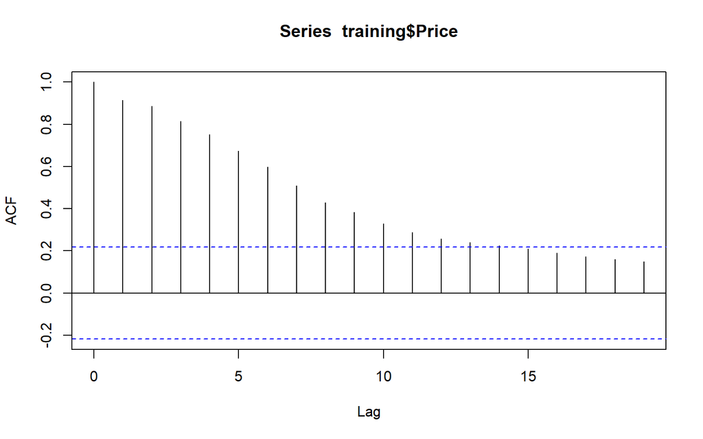

```r
acf(training$Price)
```

Berdasarkan plot ACF, terlihat bahwa plot ACF pada data train menurun secara perlahan (*tails off slowly*) yang menandakan data tidak stasioner dalam rataan.

## Data Test

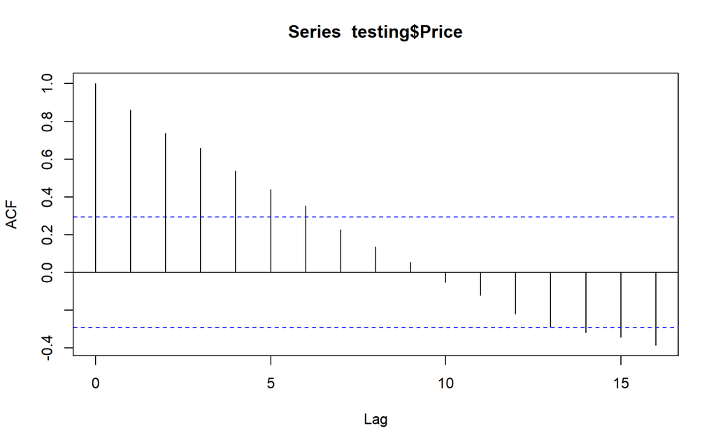

```r
acf(testing$Price)
```

Berdasarkan plot ACF, terlihat bahwa plot ACF pada data test menurun secara perlahan (*tails off slowly*) yang menandakan data tidak stasioner dalam rataan.

# Uji ADF

Hipotesis:

$H_0$ : Data tidak stasioner dalam rataan

$H_1$ : Data stasioner dalam rataan

## Data Train

```r
adf.test(training$Price)
```

```
##
##  Augmented Dickey-Fuller Test
##
## data:  training$Price
## Dickey-Fuller = -1.529, Lag order = 4, p-value = 0.7686
## alternative hypothesis: stationary
```

Berdasarkan uji ADF tersebut, didapat *p-value* sebesar 0.7686 yang lebih besar dari taraf nyata 5% dan menandakan bahwa data train tidak stasioner dalam rataan. Hal ini sesuai dengan hasil eksplorasi menggunakan plot time series dan plot ACF.

## Data Test

```r
adf.test(testing$Price)
```

```
##
##  Augmented Dickey-Fuller Test
##
## data:  testing$Price
## Dickey-Fuller = -1.5845, Lag order = 3, p-value = 0.7387
## alternative hypothesis: stationary
```

Berdasarkan uji ADF tersebut, didapat *p-value* sebesar 0.7387 yang lebih besar dari taraf nyata 5% dan menandakan bahwa data test tidak stasioner dalam rataan. Hal ini sesuai dengan hasil eksplorasi menggunakan plot time series dan plot ACF.

# Plot Box-Cox

## Data Train

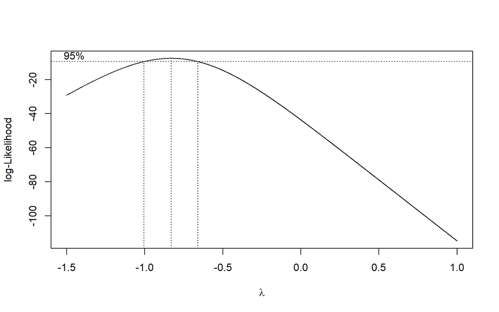

```r
training$Date <- seq(1:length(train.ts))

# Uji Box-Cox
bc1 <- boxcox(
  training$Price ~ training$Date,
  lambda = seq(-1.5, 1, by = 0.001)
)
```

```r
# Nilai lambda optimum (dibulatkan)
lambda1 <- bc1$x[which.max(bc1$y)]
lambda1
```

```
## [1] -0.83
```

```r
# Selang kepercayaan 95% untuk lambda
ci_lambda1 <- bc1$x[bc1$y > max(bc1$y) - 0.5 * qchisq(0.95, 1)]

# Batas bawah dan batas atas
ci_lower1 <- min(ci_lambda1)
ci_upper1 <- max(ci_lambda1)

c(Batas_Bawah = ci_lower1, Batas_Atas = ci_upper1)
```

```
## Batas_Bawah  Batas_Atas
##      -1.004      -0.661
```

Hasil uji Box–Cox menunjukkan bahwa nilai λ optimum adalah -0.83 dengan interval kepercayaan 95% sebesar (-1.004 hingga -0.661). Karena selang tersebut tidak memuat nilai λ = 1, maka dapat disimpulkan bahwa data tidak stasioner dalam ragam sehingga diperlukan transformasi.

## Data Test

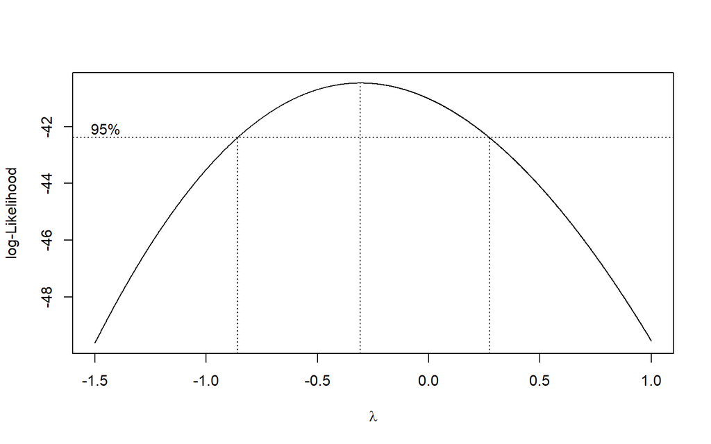

```r
testing$Date <- seq(from = length(train.ts) + 1,
                    by = 1,
                    length.out = nrow(testing))

# Uji Box-Cox
bc2 <- boxcox(
  testing$Price ~ testing$Date,
  lambda = seq(-1.5, 1, by = 0.001)
)
```

```r
# Nilai lambda optimum (dibulatkan)
lambda2 <- bc2$x[which.max(bc2$y)]
lambda2
```

```
## [1] -0.307
```

```r
# Selang kepercayaan 95% untuk lambda
ci_lambda2 <- bc2$x[bc2$y > max(bc2$y) - 0.5 * qchisq(0.95, 1)]

# Batas bawah dan batas atas
ci_lower2 <- min(ci_lambda2)
ci_upper2 <- max(ci_lambda2)

c(Batas_Bawah = ci_lower2, Batas_Atas = ci_upper2)
```

```
## Batas_Bawah  Batas_Atas
##      -0.859       0.272
```

# Penanganan Stasioneritas pada Data Train

## Differencing

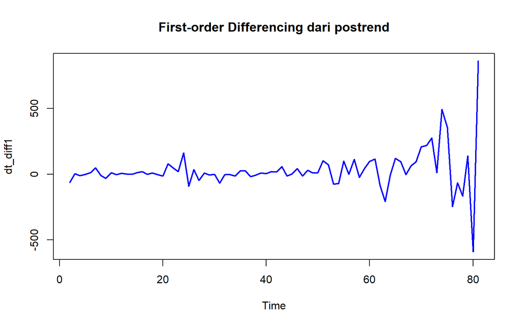

```r
# Differencing pertama pada postrend
dt_diff1 <- diff(train.ts, differences = 1)

# Plot hasil differencing
ts.plot(dt_diff1,
        main = "First-order Differencing dari postrend",
        col = "blue", lwd = 2)
```

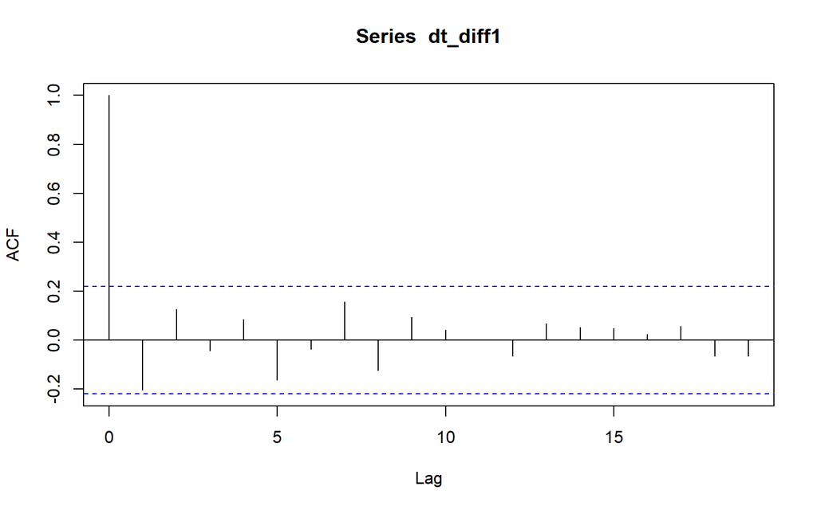

```r
# Plot ACF
acf(dt_diff1)
```

```r
# Uji ADF
adf.test(dt_diff1)
```

```
##
##  Augmented Dickey-Fuller Test
##
## data:  dt_diff1
## Dickey-Fuller = -4.6746, Lag order = 4, p-value = 0.01
## alternative hypothesis: stationary
```

Berdasarkan uji ADF tersebut, didapat *p-value* sebesar 0.01 yang lebih kecil dari taraf nyata 5% dan menandakan bahwa data train sudah stasioner dalam rataan. Hal ini sesuai dengan hasil eksplorasi menggunakan plot time series dan plot ACF.

## Plot Box-Cox

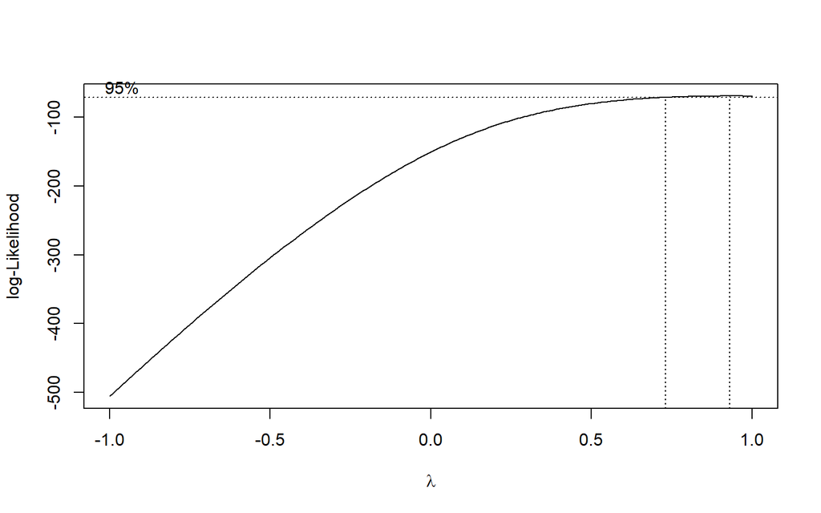

```r
training <- training[-1, ]   # buang baris pertama
training$Price <- dt_diff1 - min(dt_diff1) + 1
training$Date <- seq_along(dt_diff1)

bc3 <- boxcox(
  lm(Price ~ Date, data = training),
  lambda = seq(-1, 1, by = 0.01)
)
```

```r
# Nilai lambda optimum (dibulatkan)
lambda3 <- bc3$x[which.max(bc3$y)]
lambda3
```

```
## [1] 0.93
```

```r
# Selang kepercayaan 95% untuk lambda
ci_lambda3 <- bc3$x[bc3$y > max(bc3$y) - 0.5 * qchisq(0.95, 1)]

# Batas bawah dan batas atas
ci_lower3 <- min(ci_lambda3)
ci_upper3 <- max(ci_lambda3)

c(Batas_Bawah = ci_lower3, Batas_Atas = ci_upper3)
```

```
## Batas_Bawah  Batas_Atas
##        0.74        1.00
```

Hasil uji Box–Cox menunjukkan bahwa nilai λ optimum adalah 0.93 dengan interval kepercayaan 95% sebesar (0.74 hingga 1.00). Karena selang tersebut memuat nilai λ = 1 dan nilai λ optimum mendekati 1, maka dapat disimpulkan bahwa data train sudah stasioner dalam ragam.